# **Sequential Search/Linear Search**

**Sequential Search** merupakan teknik pencarian data dengan cara membandingkan data yang dicari dengan seluruh data yang terdapat pada kumpulan data secara satu persatu, mulai dari data pertama sampai dengan data terakhir. Ilustrasi sequential search ini dapat dilihat pada Gambar 1 berikut.

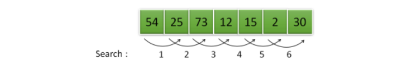

**Gambar 1. Sequential Search**

Terdapat dua konsep untuk sequential search berdasarkan kumpulan data yang akan dicari, yaitu

1. Unordered List Sequential Search
2. Ordered List Sequential Search

## **Unordered List Sequential Search**

Pada unordered list sequential search, data berada pada keadaan acak, tidak terurut, sehingga pencarian harus dilakukan mulai dari indeks awal sampai indeks terakhir dari data, atau pencarian berhenti ketika data sudah ditemukan

### Code

Berikut implementasi algoritma *unordered list sequential search*

```python
def seqSearch(listData, data):
    ind = 0
    found = False

    while ind < len(listData) and not found:
        if listData[ind] == data:
            found = True
        else:
            ind += 1

    return found
```

```python
a = [12,5,9,8,1,10,26]
```

```python
seqSearch(a,1)
```

```
True
```

### Latihan-1:

1. Modifikasi program sequential tersebut agar mengembalikan 'Data tidak ada' jika data tidak ditemukan dan mengembalikan index data jika data ditemukan

```python
def seqSearch(listData, data):
    ind = 0
    found = False

    while ind < len(listData) and not found:
        if listData[ind] == data:
            found = True
        else:
            ind += 1

    if found == True:
        return ind
    else:
        return "Data tidak ada"

# Main Program
a = [12,5,9,8,1,10,26]
seqSearch(a,12)
```

```
0
```

2. Modifikasi program sequential tersebut agar tetap meneruskan pencarian sampai data terakhir, dan kembalikan index data semua data yang ditemukan (asumsi, ada data yang sama)

```python
def seqSearch(listData, data):
    ind = []
    found = False

    for i in range(len(listData)):
        if listData[i] == data:
            ind.append(i)
            found = True

    if found == True:
        return ind
    else:
        return "Data tidak ada"

# Main Program
a = [12,5,9,8,1,10,26,12,12]
seqSearch(a,12)
```

```
[0, 7, 8]
```

```python
def seqSearch(listData, data):
    ind = 0
    found = False
    temp = []

    while ind < len(listData):
        if listData[ind] == data:
            found = True
            temp.append(ind)

        # Pindahkan ind += 1 ke luar blok if-else agar selalu dieksekusi
        ind += 1

    if found == True:
        return temp
    else:
        return "Data tidak ada"

# Main Program
a = [12, 5, 9, 8, 1, 10, 26]
print(seqSearch(a, 12))
# Tambahkan print() untuk melihat hasilnya di terminal
```

```
[0]
```

**Kebali ke Menu Awal**

## **Ordered List Sequential Search**

Pada ordered list sequential search, data sudah dalam keadaan terurut, hal ini tentunya dapat mengurangi waktu komputasi pencarian. Ilustrasi algoritma pencarian ini, dapat dilihat pada Gambar 2 berikut:

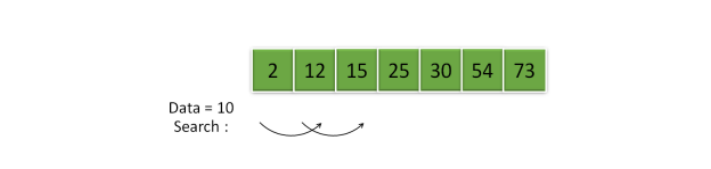

**Gambar 2. Ordered List Sequential Search**

Berikut implementasi algoritma sequential search pada ordered list

```python
def orderedSeqSearch(listData, data):
    ind = 0
    found = False
    stop = False
    position = []

    while ind < len(listData) and not found and not stop:
        if listData[ind] == data:
            found = True
            position.append(ind)
        else:
            if listData[ind] > data:
                stop = True
            else:
                ind += 1

    if found:
        return ind
    else:
        return "Data tidak ada"

# Main Program
a=[1,1,5,5,5,8,9,10,12,26]
ind=orderedSeqSearch(a,5)
print(ind)
```

```
2
```

**Kebali ke Menu Awal**

## **Analisis Kompleksitas Waktu**

Dalam rekayasa perangkat lunak, kita perlu tahu seberapa efisien sebuah algoritma saat jumlah data ($N$) semakin membesar.

- **Unordered List Sequential Search**:
  - Best Case (Kasus Terbaik): $O(1)$ — Data yang dicari berada di indeks paling pertama.
  - Worst Case (Kasus Terburuk): $O(N)$ — Data berada di indeks paling akhir, atau tidak ada di dalam list sama sekali. Program harus mengecek seluruh elemen.
- **Ordered List Sequential Search**:
  - Best Case: $O(1)$ — Data ditemukan di indeks pertama.
  - Worst Case: $O(N)$ — Data ada di akhir list. Namun, jika data tidak ada, algoritma ini sedikit lebih efisien secara rata-rata dibandingkan unordered karena pencarian bisa dihentikan lebih awal (kondisi stop = True) begitu menemukan elemen yang lebih besar dari target.

## **Sequential Search pada List of Dictionaries**

Di dunia nyata, data jarang berupa list angka sederhana. Biasanya, kita mengolah kumpulan objek atau dictionary. Konsep sequential search tetap sama, hanya cara mengakses nilainya yang berbeda.

```python
def search_dict_list(data_list, key, target):
    for i in range(len(data_list)):
        if data_list[i][key] == target:
            return i
    return -1
```